# Option Lab: Cost Function

[figure not shown]

### Goals

이 실습에서는 다음을 수행한다.

- 하나의 변수를 허용하는 선형 회귀에 대한 비용(cost) 함수를 구현하고 탐색합니다.

### Tools

이 실습에서는 다음을 활용합니다.

- Numpy: 과학 컴퓨팅을 위한 인기 라이브러리
- Matplotlib: 데이터 플로팅에 널리 사용되는 라이브러리
- 로컬 디렉토리에 있는 lab_utils_uni.py 파일의 플로팅 루틴

```python
#!pip install ipympl

import numpy as np
%matplotlib widget
import matplotlib.pyplot as plt
from lab_utils_uni import plt_intuition, plt_stationary, plt_update_onclick, soup_bowl
plt.style.use('deeplearning.mplstyle')
```

### Problem Statement

당신은 집의 크기를 고려하여 주택 가격을 예측할 수 있는 모델을 원합니다. 이전 실습과 동일한 두 개의 데이터 포인트를 사용해 보겠습니다. 1000평방피트의 주택은 $300,000에 팔렸고 2000평방피트의 주택은 $500,000에 팔렸습니다.

[output not shown]

```python
x_train=np.array([1.0, 2.0])
y_train=np.array([300.0, 500.0])
```

### Computing Cost

이 과제에서 '비용(cost)'이라는 용어는 데이터가 주택 비용(cost)이기 때문에 약간 혼란스러울 수 있습니다. 여기서 비용(cost)은 모델이 주택의 목표 가격을 얼마나 잘 예측하고 있는 지를 측정한 것입니다. 주택 데이터에는 '가격(price)'이라는 용어가 사용됩니다.

변수가 하나인 비용(cost) 방정식은 다음과 같습니다.

[figure not shown]

```python
def compute_cost(x, y, w, b):
    #number of training examples
    m=x.shape[0]

    cost_sum=0
    for i in range(m):
        f_wb=w*x[i]+b
        cost=(f_wb-y[i])**2
        cost_sum=cost_sum+cost
    total_cost=(1/(2*m))*cost_sum

    return total_cost
```

### Cost Function Intuition

[figure not shown]

여러분의 목표는 입력 x 에 대해 주택 가치를 정확하게 예측하는 w,b 매개변수를 사용하여 fw,b(x)=wx+b 모델을 찾는 것입니다. 비용은 모델이 훈련 데이터에 대해 얼마나 정확한지를 측정한 것입니다. 위의 비용 방정식 (1)은 예측 f<sub>w,b</sub>(x) 가 대상 데이터 y와 일치하도록 w 및 b 를 선택할 수 있는 경우 (f<sub>w,b</sub>(x<sup>(i)</sup>)−y<sup>(i)</sup>)<sup>2</sup> 항은 0이 되고 비용은 최소화됩니다. 이 간단한 2점 예제에서 이를 달성할 수 있습니다! 이전 실습에서는 b=100 이 최적의 솔루션을 제공한다고 판단했으므로 b 를 100으로 설정하고 w 에 집중하겠습니다. 아래에서는 슬라이더 컨트롤을 사용하여 비용을 최소화하는 w 값을 선택합니다. 플롯이 업데이트되는 데 몇 초 정도 걸릴 수 있습니다.

```python
plt_intuition(x_train,y_train)
```

```
interactive(children=(IntSlider(value=150, description='w', max=400, step=10), Output()), _dom_classes=('widge…
```

위의 그림에는 언급할 가치가 있는 몇 가지 요소가 포함되어 있습니다.

- **w=200**일 때 비용이 최소화되며 이는 이전 실습의 결과와 일치합나다.
- 목표와 예측의 차이는 비용 방정식에서 제곱되기 때문에 w가 너무 크거나 작을 경우 비용이 급격히 증가합니다.
- 비용을 최소화하여 선택한 w와 b를 사용하면 데이터에 완벽하게 맞는 선이 생성됩니다.

### Cost Function Visualization-3D

3D로 플롯하거나 등고선 플롯을 사용하면 w 및 b 둘 다와 관련하여 비용이 어떻게 달라지는지 확인할 수 있습니다. 이 과정의 일부 구성이 상당히 복잡해질 수 있다는 점은 주목할 가치가 있습니다. 플로팅 루틴이 제공되며 코드를 읽어서 방법에 익숙해지는 것이 유익할 수 있지만, 과정을 성공적으로 완료하는 데 꼭 필요한 것은 아닙니다. 루틴은 로컬 디렉터리의 lab_utils_uin.py에 있습니다.

#### Large Data Set

몇 가지 추가 데이터 포인트가 포함된 시나리오를 보는 것이 유익합니다. 이 데이터 세트에는 동일한 선에 속하지 않는 데이터 포인트가 포함되어 있습니다. 비용 방정식에서 이는 무엇을 의미합니까? 비용이 0이 되는 w와 b를 찾을 수 있나요?

```python
x_train=np.array([1.0, 1.7, 2.0, 2.5, 3.0, 3.2])
y_train=np.array([250, 300, 480, 430, 630, 730])
```

등고선도에서 점을 클릭하여 'w'와 'b'를 선택하여 최저 비용을 달성합니다. 등고선을 사용하여 선택을 안내하세요. 그래프를 업데이트하는 데 몇 초 정도 걸릴 수 있습니다.

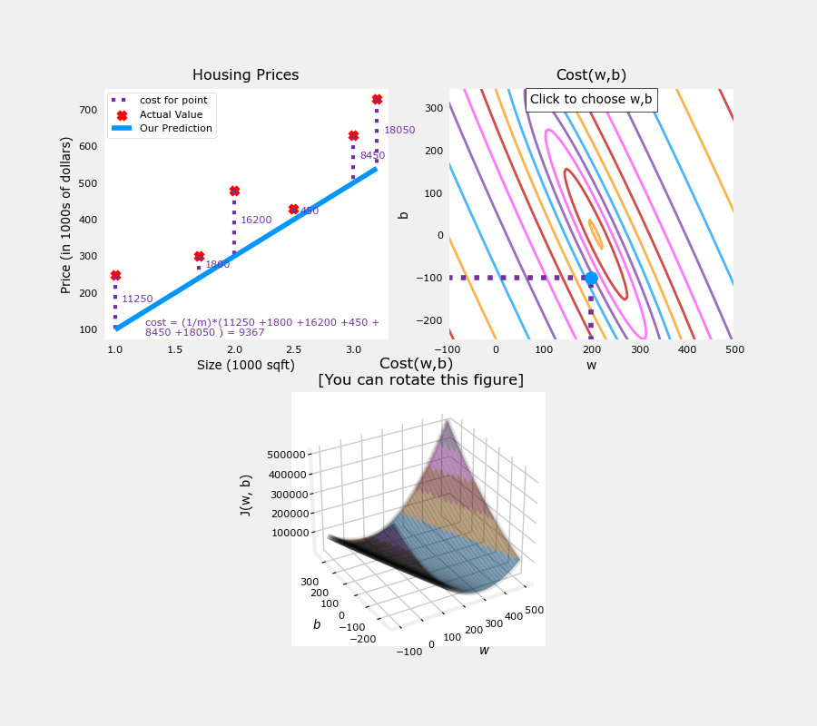

```python
plt.close('all')
fig, ax, dyn_items=plt_stationary(x_train, y_train)
updater=plt_update_onclick(fig, ax, x_train,y_train, dyn_items)
```

위의 왼쪽 그림에서 점선을 확인하세요. 이는 훈련 세트의 각 예제가 기여하는 비용 부분을 나타냅니다. 이 경우 약 w=209 및 b=2.4 의 값이 저렴한 비용을 제공합니다. 훈련 자료들이 한 줄에 놓여 있지 않기 때문에 최소 비용은 0이 아닙니다.

#### Convex Cost surface

비용 함수가 손실을 제곱한다는 사실은 '오차 표면'이 수프 사발처럼 볼록(convex)하다는 것을 보장합니다. 모든 차원에서 그래디언트를 따르면 항상 도달할 수 있는 최소값이 있습니다. 이전 플롯에서는 w와 b차원의 크기가 각각 다르기 때문에 이를 인식하기가 쉽지 않습니다. w와 b가 대칭인 다음 플롯이 강의에 표시되었습니다.

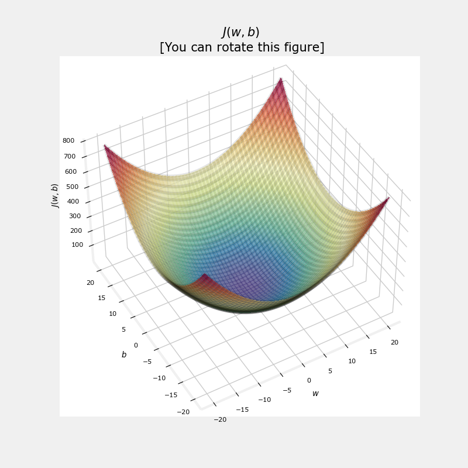

```python
soup_bowl()
```